# | China - Credit

Macro Research

08 Oct, 2026

# Credit

## Summary

### TSF

| Net change (CNY, Billions) NSA Categorias | Net change (CNY, Billions) NSA Compared vs 12m prior (delta) | Net change (CNY, Billions) NSA Sep/26 | Net change (CNY, Billions) NSA Aug/26 | Net change (CNY, Billions) NSA Jul/26 | Net change (CNY, Billions) NSA Jun/26 | Net change (CNY, Billions) NSA May/26 | Net change (CNY, Billions) NSA Apr/26 | Net change (CNY, Billions) NSA Sep/25 |
| --- | --- | --- | --- | --- | --- | --- | --- | --- |
| Aggregate Financing | NA | NA | 1520 | 1220 | 3250 | 1930 | 420 | 3430 |
| Local Currency Bank Loan | NA | NA | 60 | -590 | 1760 | 500 | -400 | 1610 |
| Foreign Currency Bank Loans | NA | NA | 40 | 10 | 40 | 10 | 10 | -10 |
| Entrusted Loans | NA | NA | 20 | 0 | 20 | -10 | -20 | 20 |
| Trust Loans | NA | NA | -20 | -20 | -50 | 0 | -10 | 10 |
| Undiscounted Bankers Acceptances | NA | NA | 40 | -50 | -110 | -70 | -530 | 320 |
| Net Financing of Corporate Bonds | NA | NA | 240 | 390 | 390 | 170 | 360 | 30 |
| Domestic Equity Financing by Non Financial Corporates | NA | NA | 70 | 110 | 60 | 30 | 90 | 50 |
| Asset-Backed Securities | NA | NA | -20 | -10 | 30 | -30 | -10 | 10 |
| Write-offs of Loans | NA | NA | 100 | 70 | 320 | 110 | 50 | 210 |
| Government Bonds | NA | NA | 1010 | 1320 | 760 | 1230 | 900 | 1190 |
| TSF ex Govt Bonds | NA | NA | 510 | -100 | 2490 | 700 | -480 | 2240 |

### Loans detailed

Categorias

Compared vs 12m prior (delta)

Sep/26

Aug/26

Jul/26

Jun/26

May/26

Apr/26

Sep/25

Domestic Loans

NA

NA

14.30

-561.95

1625.47

409.98

-224.35

1374.15

1. Loans to Households

NA

NA

-200.77

-460.23

264.58

-141.18

-786.97

391.95

1.1 HH Short Term Loans

NA

NA

-118.54

-340.02

106.14

-84.06

-446.14

142.10

1.1.1 Consumption Loans

NA

NA

-44.52

-160.95

37.09

-23.98

-205.38

-1.92

1.1.2 Operating Loans

NA

NA

-74.02

-179.07

69.05

-60.08

-240.76

144.02

1.2 HH Medium and Long-term Loans

NA

NA

-82.23

-120.21

158.44

-57.13

-340.83

249.87

1.2.1 Consumption Loans

NA

NA

-121.06

-115.65

32.92

-104.95

-299.80

74.63

1.2.2 Operating Loans

NA

NA

38.83

-4.56

125.52

47.82

-41.03

175.23

2. Loans to Non-financial Enterprises & Government & Its Associations

NA

NA

258.67

-129.62

1503.48

637.43

388.06

1217.07

2.1 Corp Short Term Loans

NA

NA

-158.37

-257.12

823.12

102.29

-457.64

712.45

2.2 Corp Medium and Long-term Loans

NA

NA

315.66

-222.32

552.30

-19.41

-408.79

903.26

2.3 Notes Financing

NA

NA

100.18

375.51

114.38

557.08

1240.10

-402.55

2.4 Financial Leases

NA

NA

0.03

-27.86

17.45

-4.80

10.01

6.30

2.5 Advances

NA

NA

1.18

2.16

-3.76

2.26

4.38

-2.38

3. Loans to Non-Banking Financial Intermediaries

NA

NA

-43.60

27.90

-142.59

-86.27

174.56

-234.88

### Money supply

| YoY (%) NSA Categorias | YoY (%) NSA Sep/26 | YoY (%) NSA Aug/26 | YoY (%) NSA Jul/26 | YoY (%) NSA Jun/26 | YoY (%) NSA May/26 | YoY (%) NSA Apr/26 | YoY (%) NSA Mar/26 | YoY (%) NSA Feb/26 | YoY (%) NSA Jan/26 |
| --- | --- | --- | --- | --- | --- | --- | --- | --- | --- |
| M0 | NA | 11.18 | 11.56 | 11.79 | 11.88 | 12.25 | 12.54 | 14.07 | 2.73 |
| M1 | NA | 4.09 | 3.97 | 3.97 | 5.49 | 4.99 | 5.14 | 5.93 | 4.91 |
| M2 | NA | 7.48 | 7.75 | 8.00 | 8.56 | 8.57 | 8.53 | 8.95 | 9.00 |

### Ordering

#### TSF

[figure not shown]

#### Loans

[figure not shown]

### Credit impulse

#### Acc 12m. as % GDP

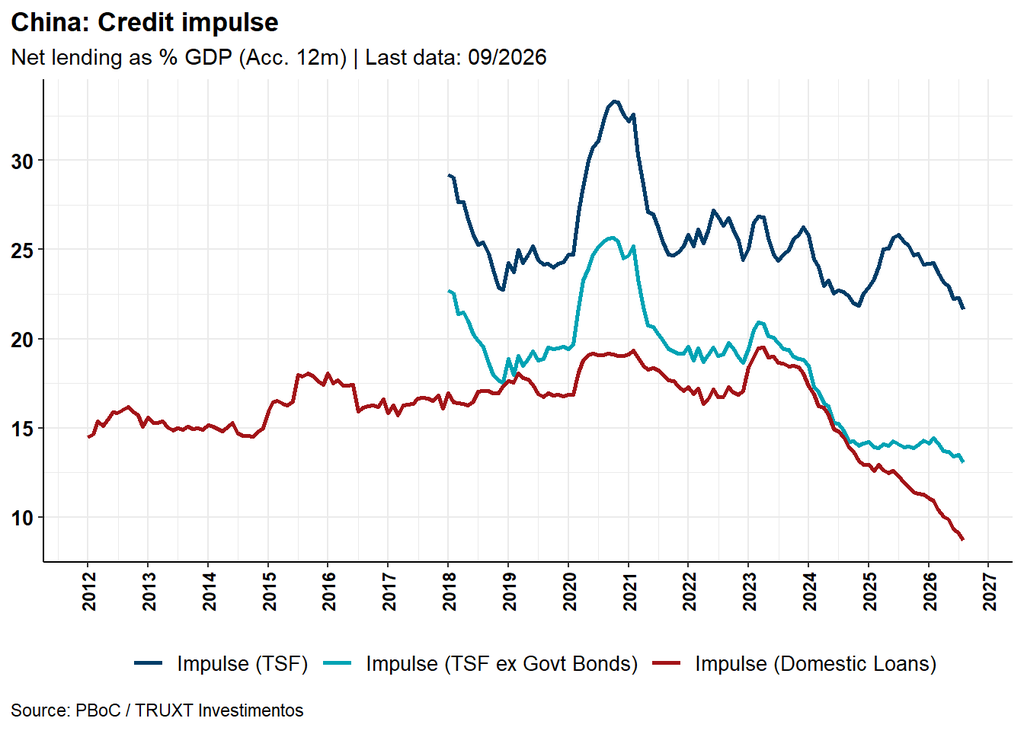

#### Impulse

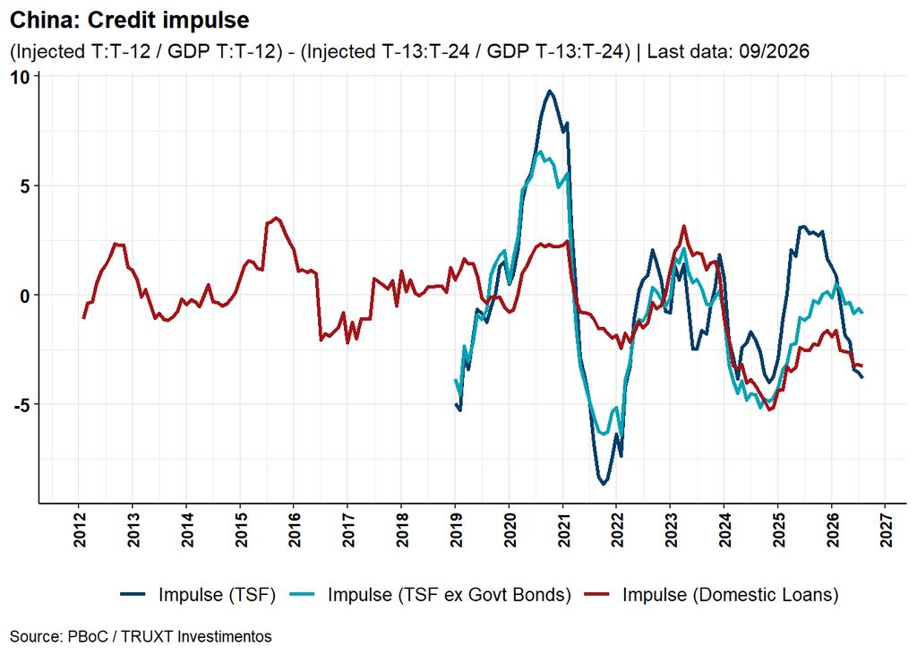

#### Growth rate vs GDP

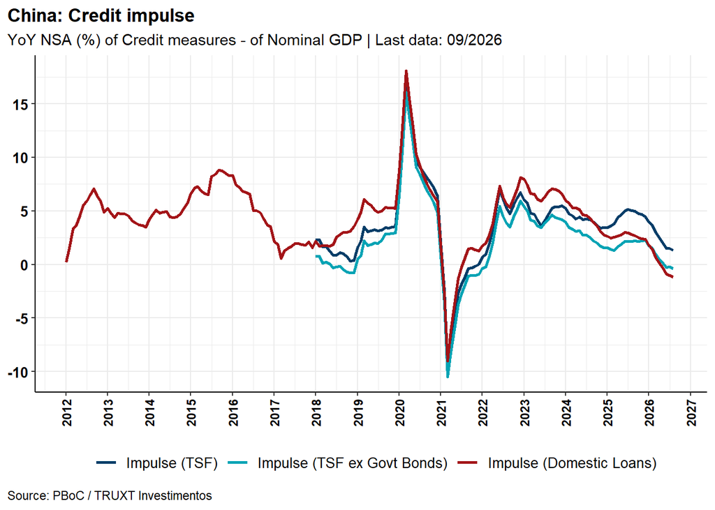

### Stock as % of GDP

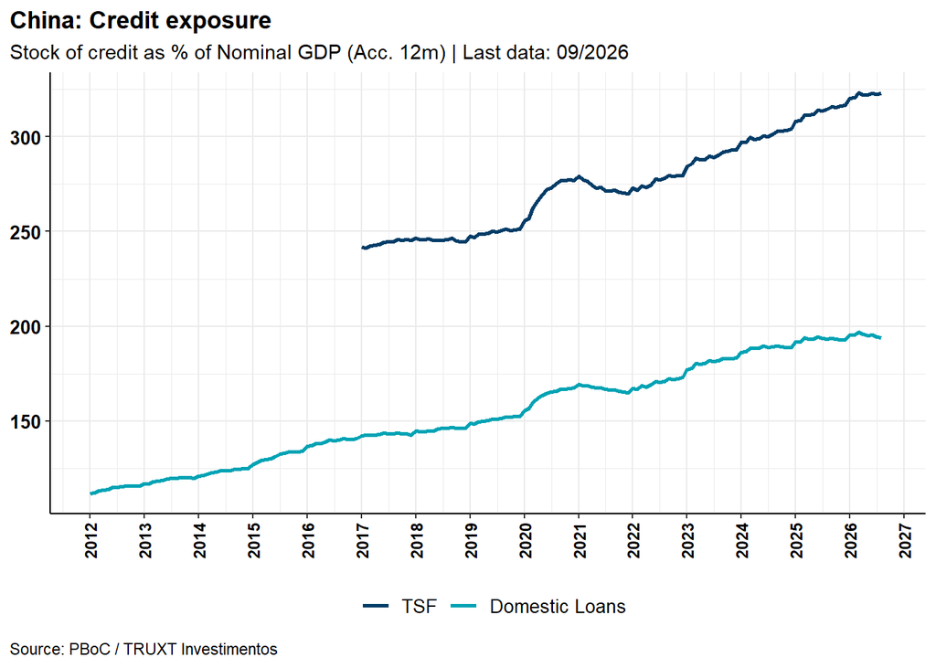

## Total Social Financing

### Headline

#### YoY

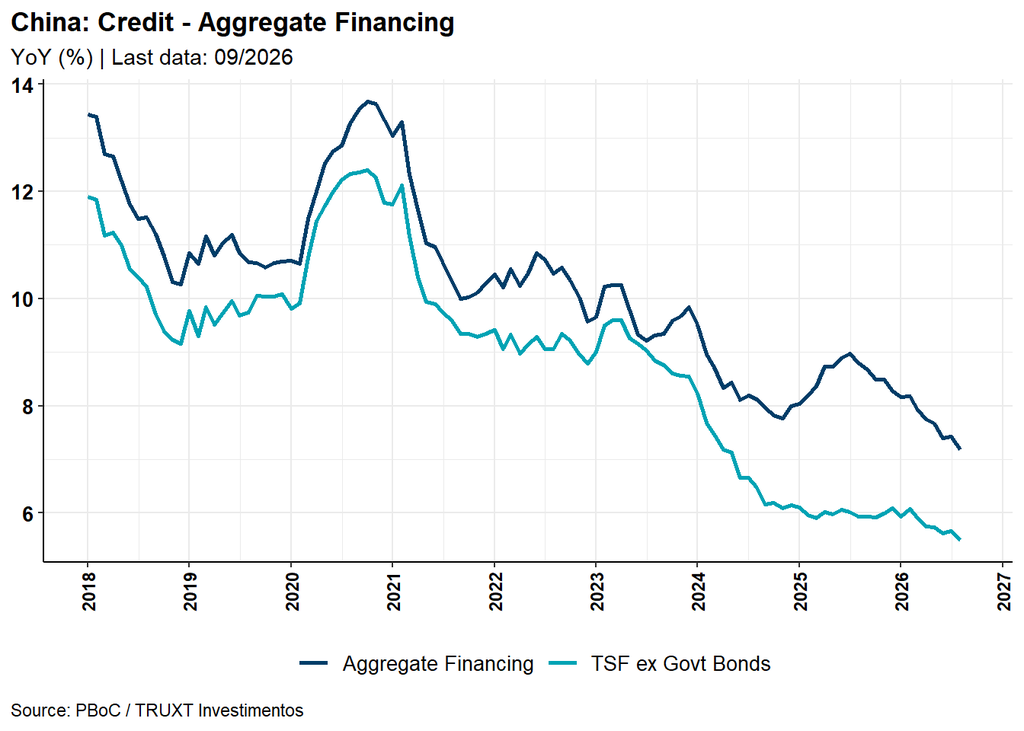

#### TSF vs Domestic Loans

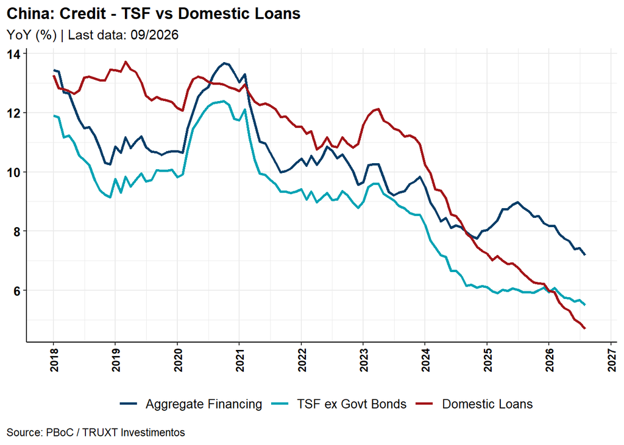

#### Sazonalidade

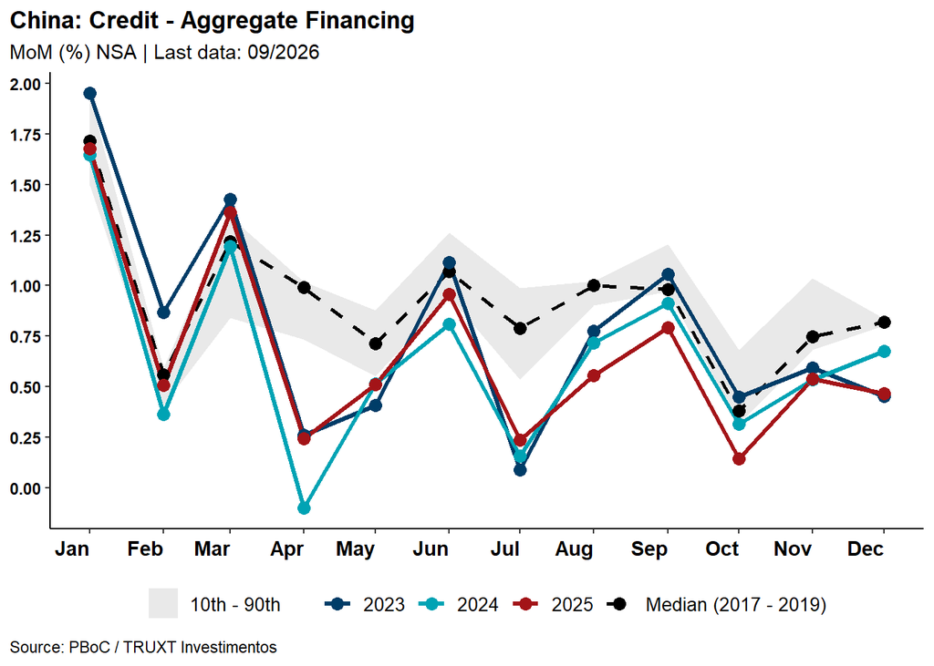

#### Sazonalidade ex govt bonds

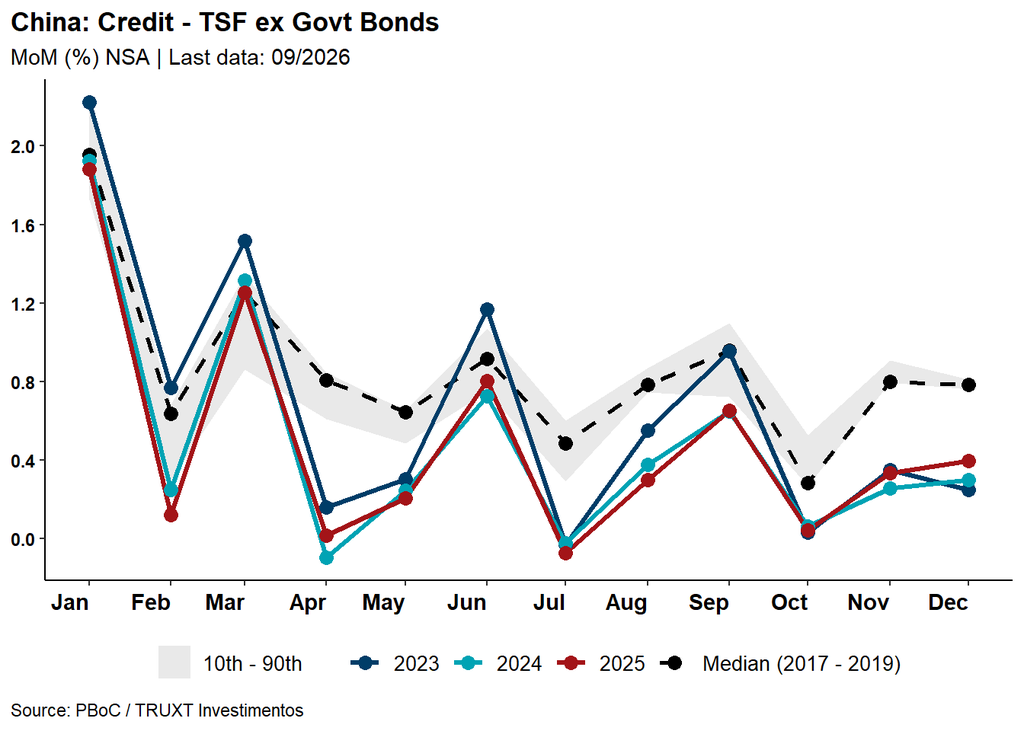

### Bank loans

#### YoY

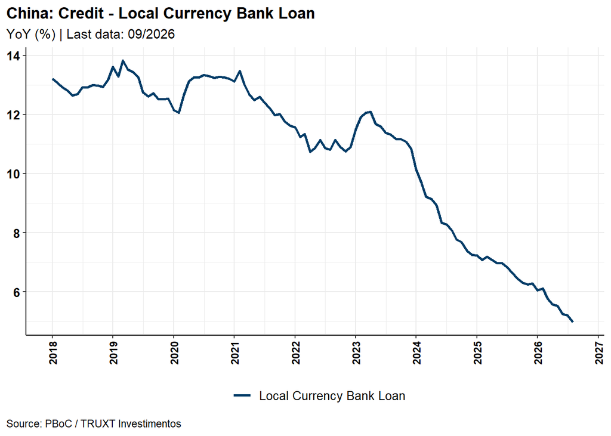

#### Sazonalidade

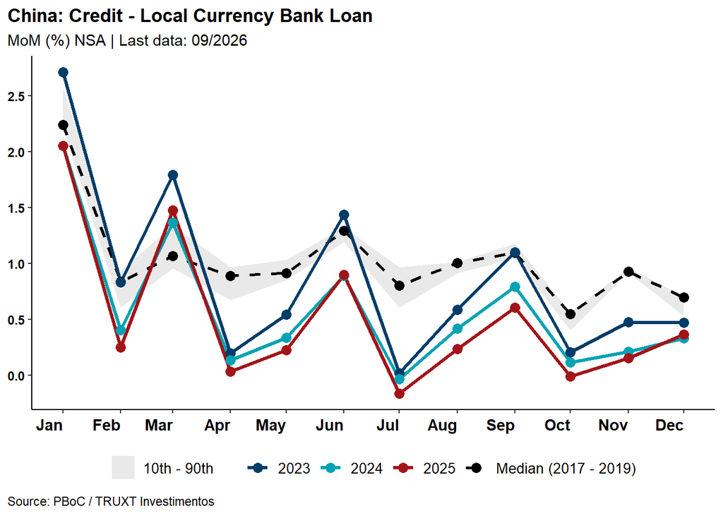

### Government Bonds

#### YoY

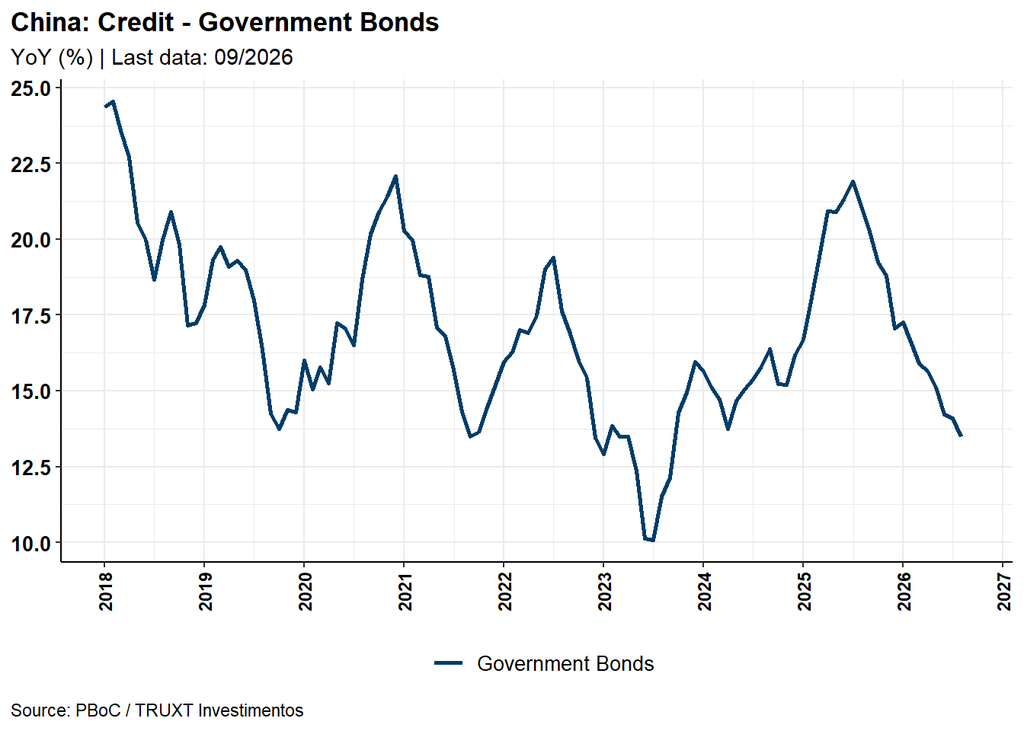

#### Sazonalidade

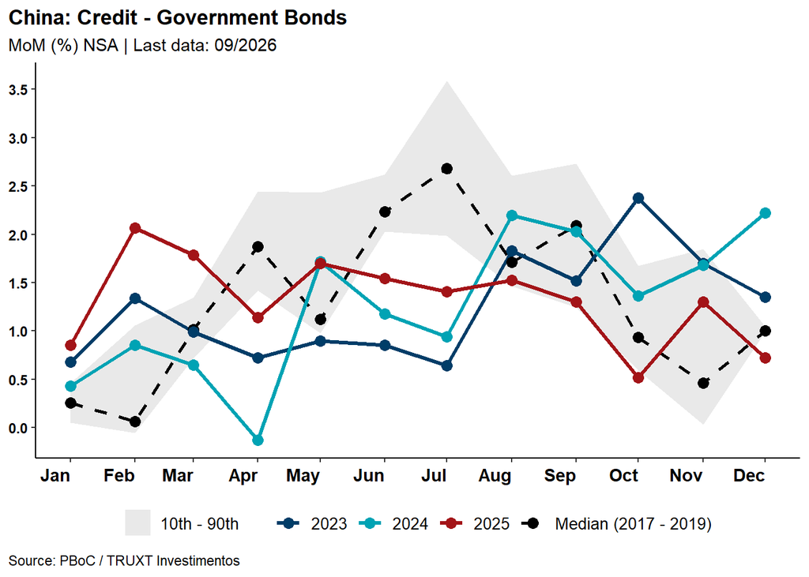

### Corporate Bonds

#### YoY

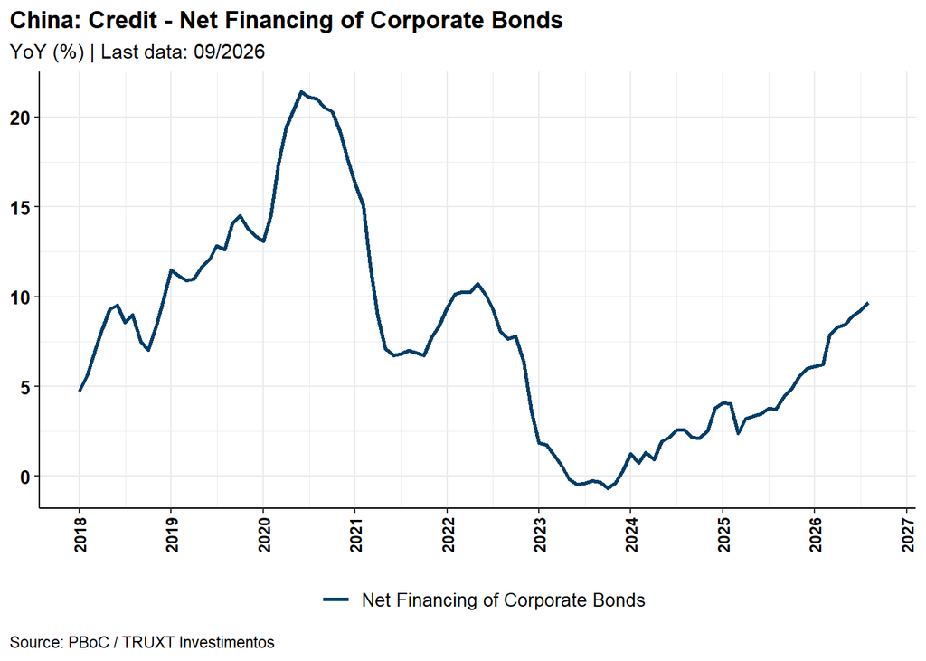

#### Sazonalidade

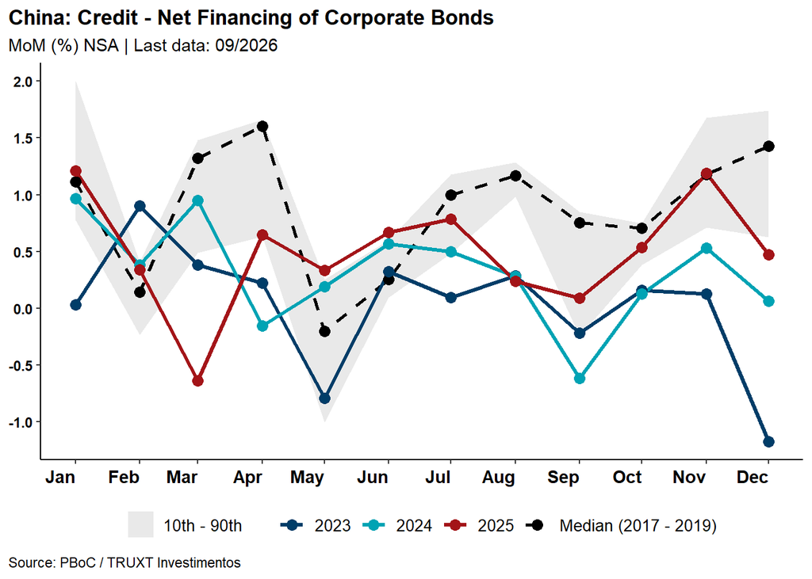

### Entrusted Loans

#### YoY

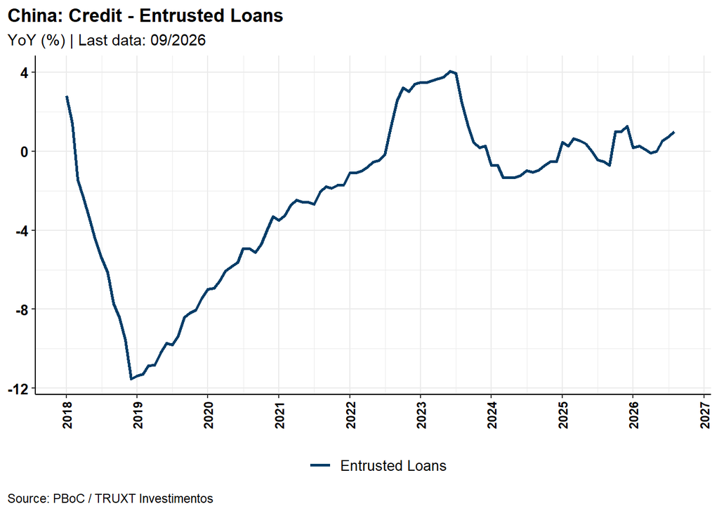

#### Sazonalidade

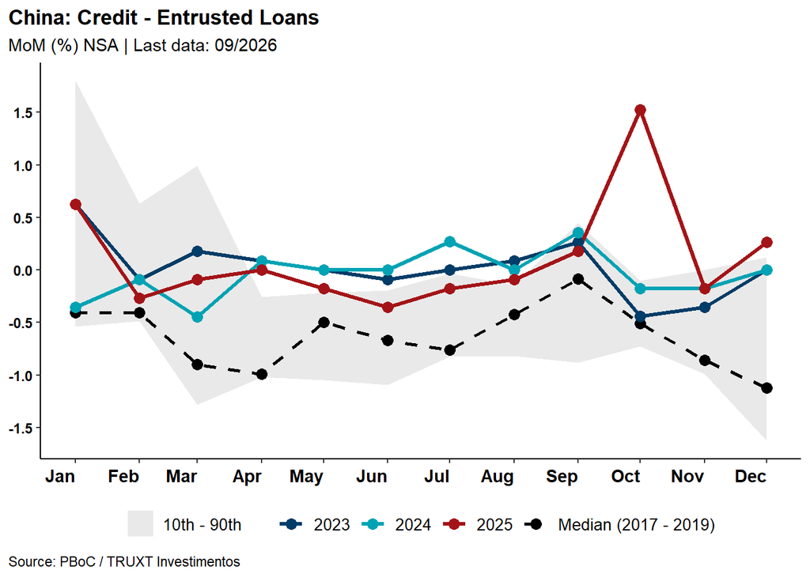

### Trust Loans

#### YoY

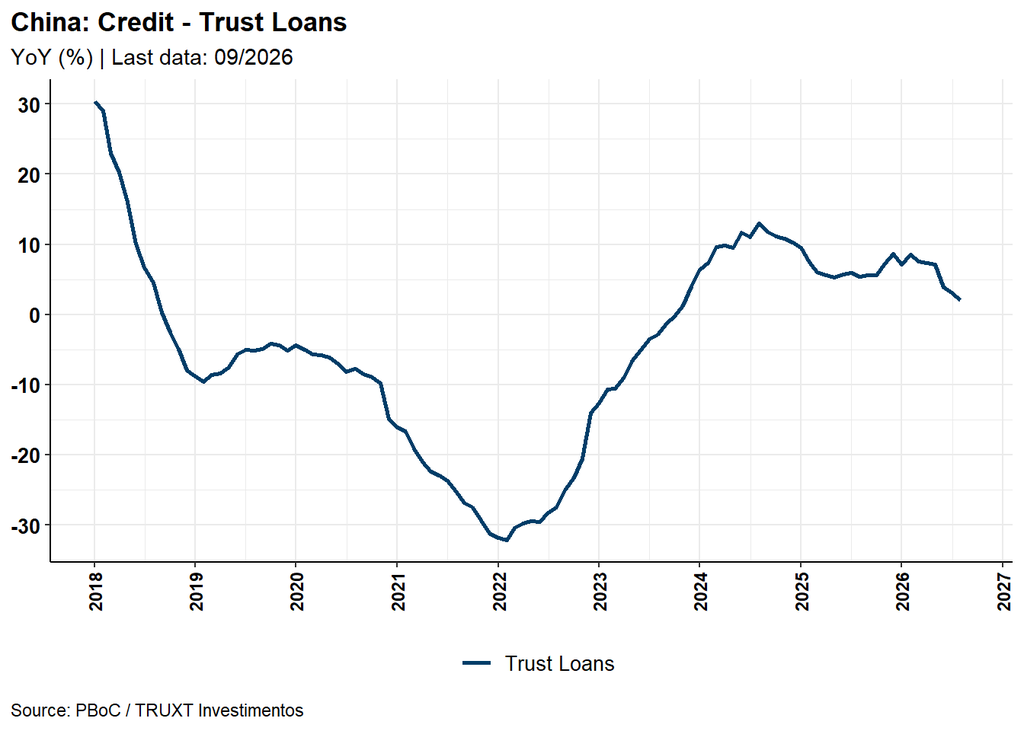

#### Sazonalidade

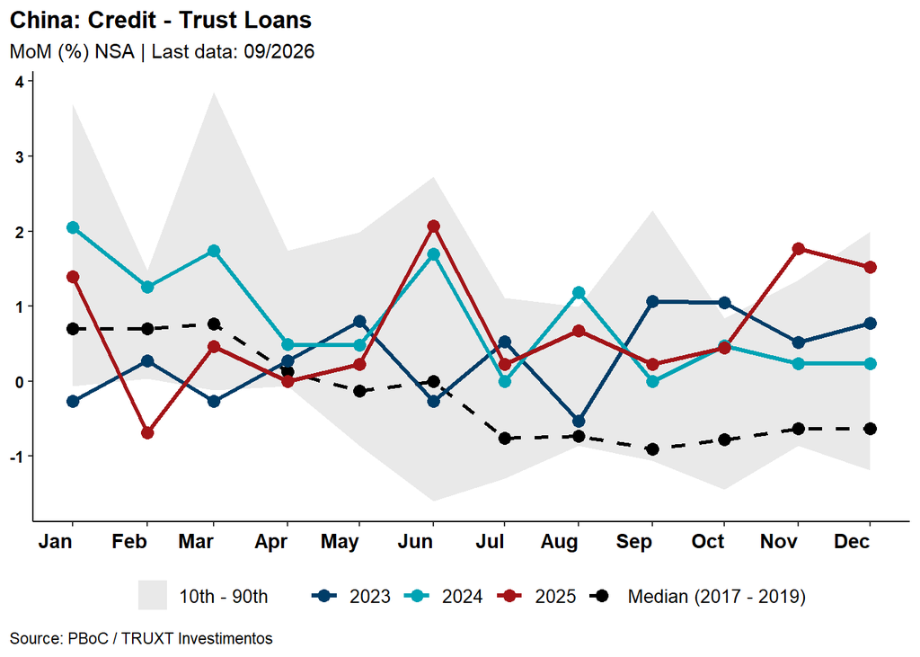

### Undiscounted Bankers Acceptances

#### YoY

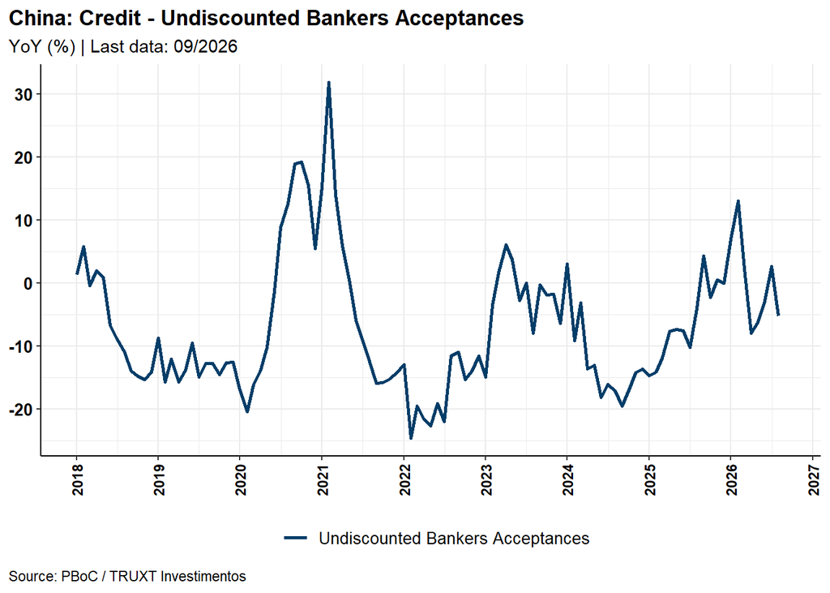

#### Sazonalidade

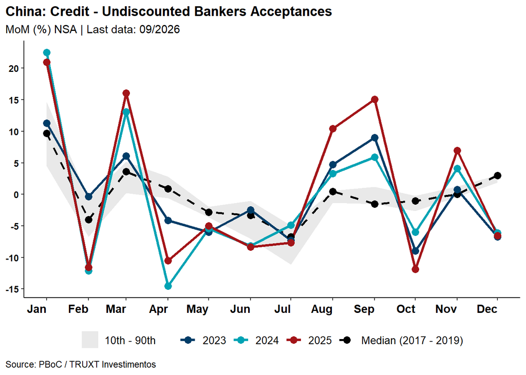

### Domestic Equity Financing Corporates

#### YoY

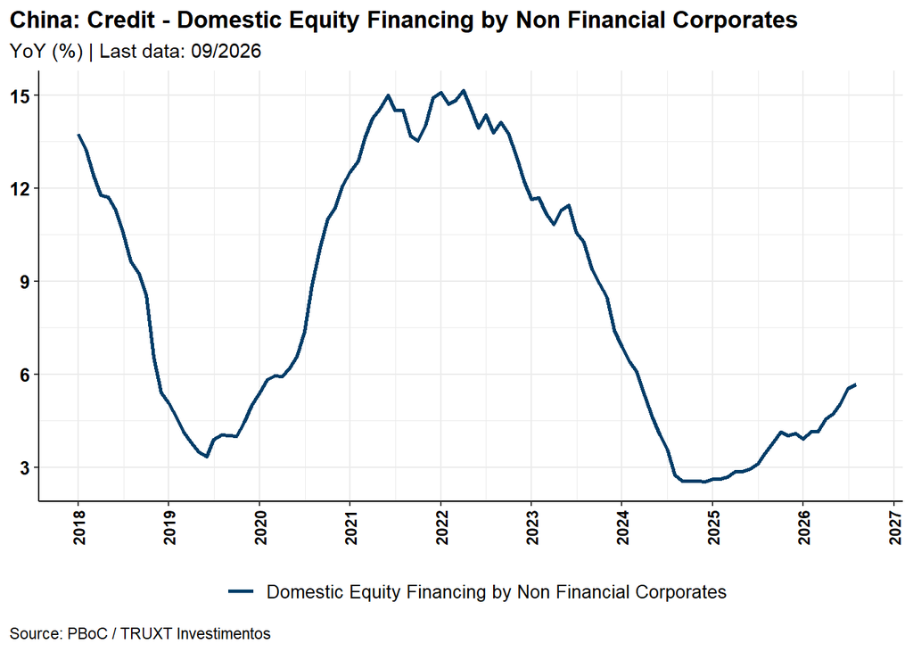

#### Sazonalidade

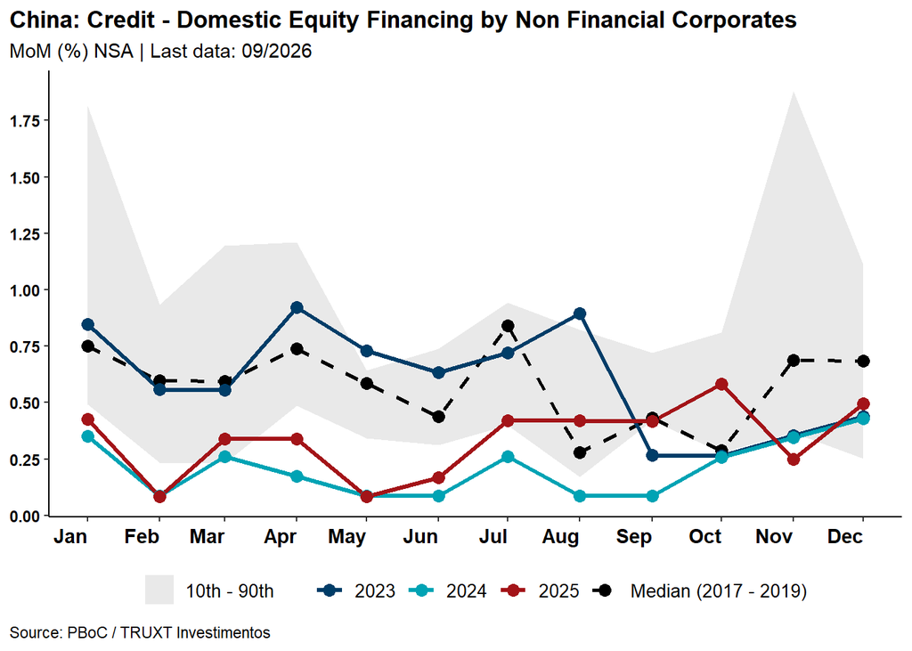

### Asset-Backed Securities

#### YoY

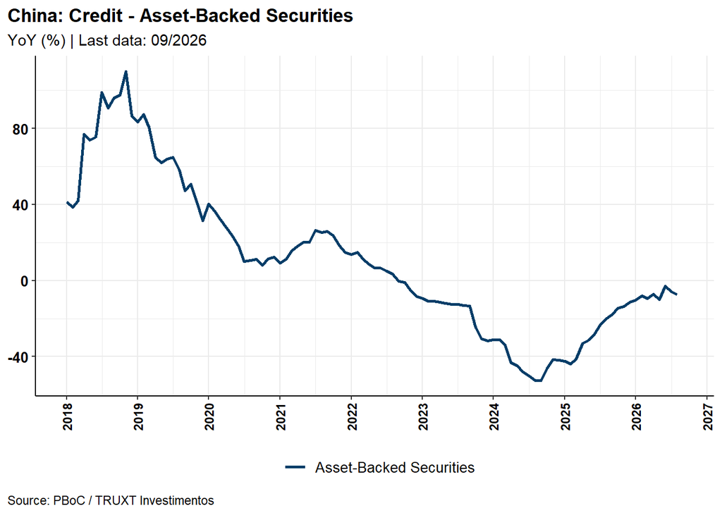

#### Sazonalidade

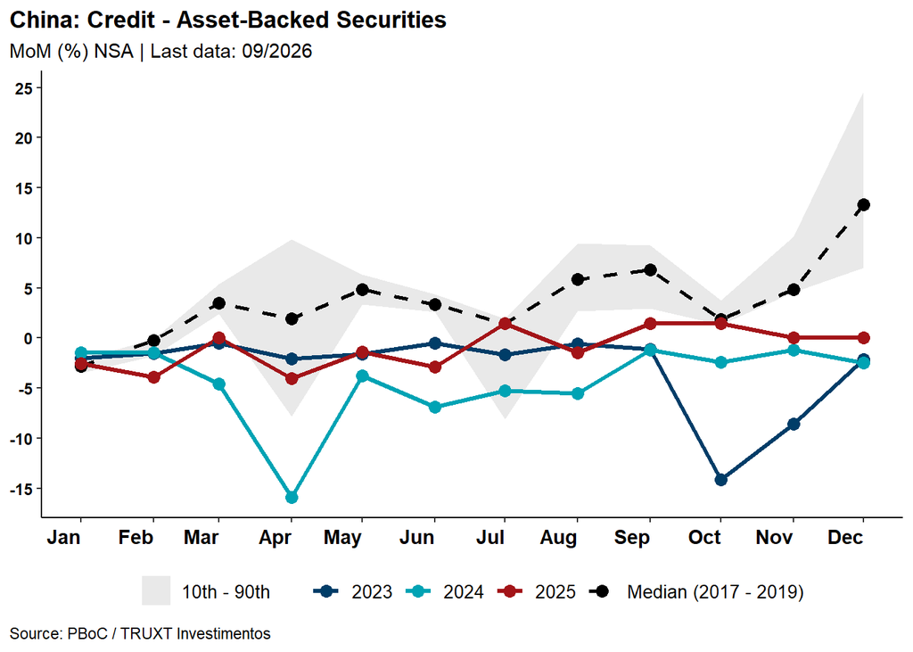

### Write-offs of Loans

#### YoY

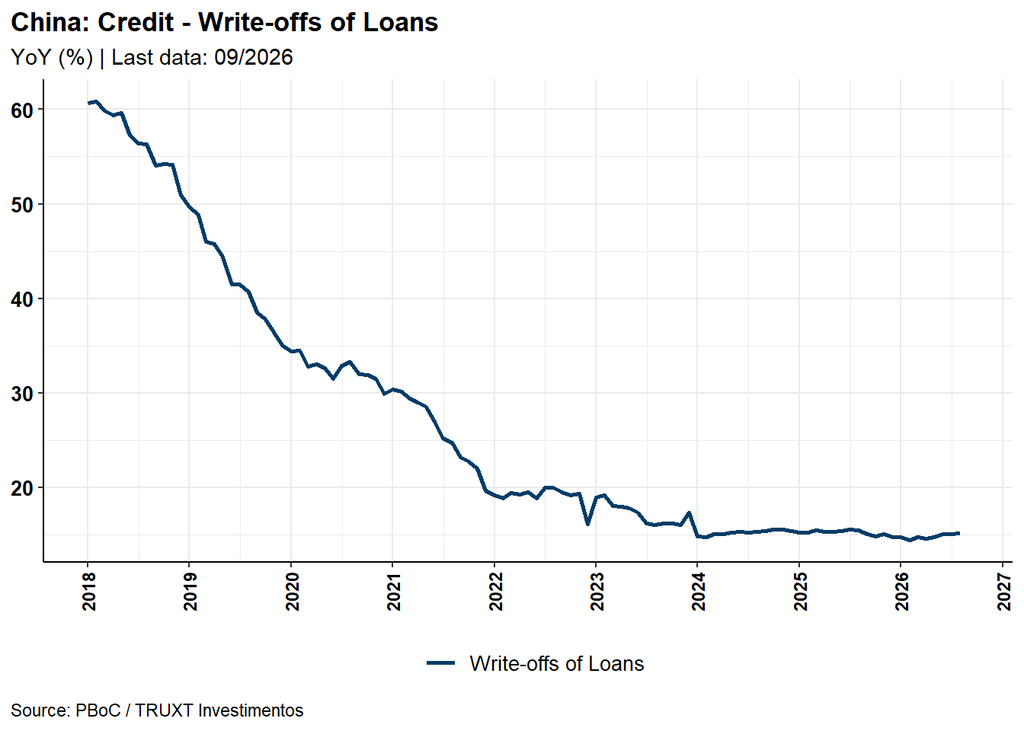

#### Sazonalidade

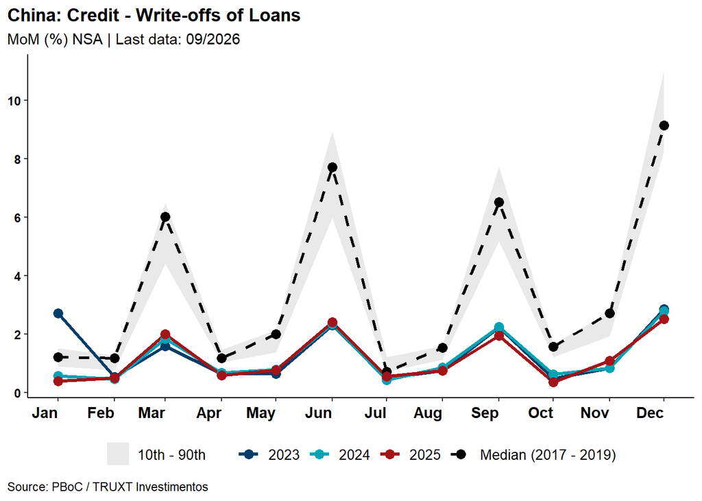

## Money supply

### M0

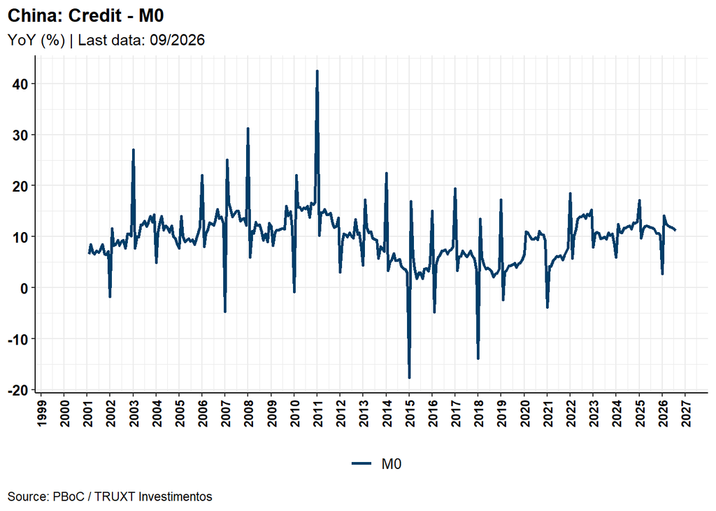

### M1

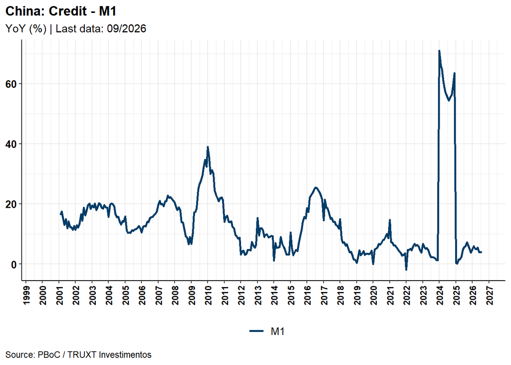

### M2

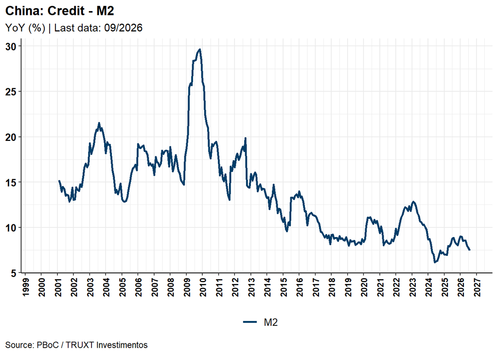